# Applied Data Analysis

Course Introduction

Professor Benjamin Noble

> “[This class] will acquaint students with statistical methodology as it is used in the social sciences.”

## Expectation…

[figure not shown]

via Silver Bulletin

[figure not shown]

## Reality…

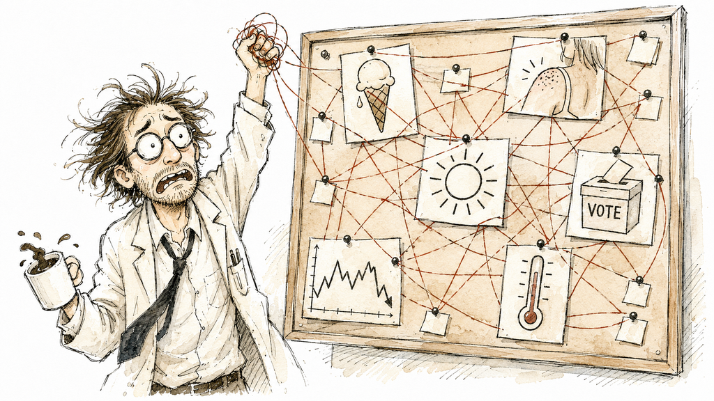

## Causal Questions in Political Science

- Does ideological extremism cause a candidate to win an election?
- Does inflation cause presidential approval to decrease?
- Does democratization cause countries to become more peaceful?

## Machine Learning

Which factors predict the outcome?

## Causal Inference

Does this factor cause the outcome?

## Correlation and Causation

[figure not shown]

via XKCD

## An Example

Does Eating Ice Cream Cause Sunburn?

## Does Being an Extremist Increase Your Election Odds?

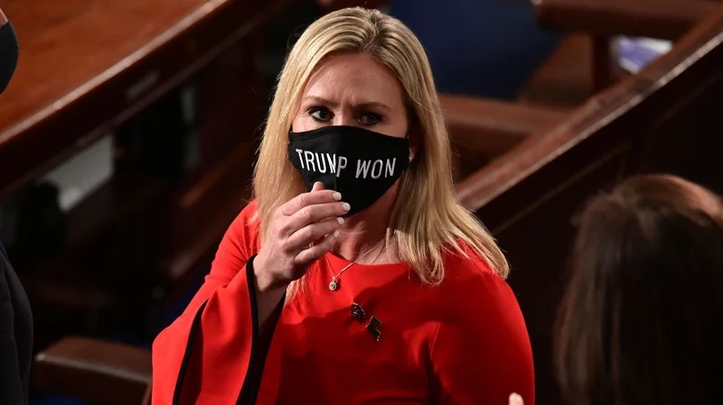

Marjorie Taylor Greene, via NPR

[figure not shown]

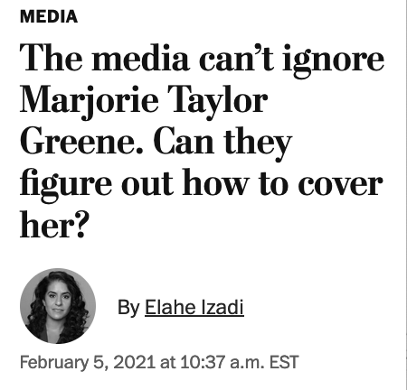

via Washington Post

## Why Not Just Control for Everything?

- What is “everything?”
- Can you measure “everything?”
- Controls can change what we’re estimating.

## About Me

[figure not shown]

- From St. Louis, MO.
- **My research:** congressional and presidential rhetoric, polarization.
- I enjoy yoga, surfing, and cooking.
- My favorite San Diego coffee shop: **Lovesong** (North Park).

## Our Class

- Our [course syllabus](https://benjaminnoble.org/teaching/causal-inference/) is linked on Canvas.
- Two meetings per week, fully remote over Zoom (link on Canvas).
  - Monday & Wednesday, 11am–1:50pm.
  - Each session mixes lecture and an in-class group lab.
- Lectures are recorded and posted to Canvas. Please keep your camera on.

## Our Textbooks

[figure not shown]

## Your Grade: Attendance and Participation (15%)

- Attend lecture synchronously.
- Keep your camera on.
- Participate actively in labs and discussion.
- One excused class absence, no questions asked.

## Your Grade: Labs (25%)

- In-class group work, submit your own files on Canvas.
- Graded on participation and effort.
- Answers will be posted after class.
- One excused absence drops that day’s lab.

## Your Grade: Homework (30%)

- Three homework assignments. You run provided R code in DataHub and enter your answers on Canvas.
- Must be done individually, but open book, note, internet.
- You have three attempts per homework.
- Late submissions minus one letter grade per 24 hours. No late submissions after solutions are posted.

## Your Grade: Oral Exam (25%)

- One-on-one conversation with me over Zoom (about 8-10 minutes), during the last two class days.
- I give you a short scenario. You talk me through how you’d answer a causal question about it.
- No coding or analysis. It’s about reasoning, not execution.
- You’ll get practice scenarios ahead of time, more details closer to the date.

## Your Grade: Final (5%)

- Asynchronous final, can be taken Friday 7/24 through Friday 7/31.
- Budget 2-3 hours.
- Similar to the homeworks, but longer and more comprehensive.
- Completed alone, but open book, notes, internet, etc.

## Your Grade

- Attendance and participation (15%)
- Labs (25%)
- Homework (30%)
- Oral Exam (25%)
- Final (5%)

## A Brief Note on R

- I’ll be teaching this class using the R programming language.
- You’ll mostly run code I provide and read the output.
- No prior programming experience needed. You won’t write R from scratch.
- Today’s lab and homework get you set up.

```r
if (my_grade >= 90) {
  print('POLI 170 is the best!')
} else {
  print('POLI 170 stinks!')
}
```

## A Brief Note on AI/LLMs

- Feel free to use AI.
- But, use it *responsibly*.

## Office Hours

- Low stakes opportunity to get help or ask questions about the course/assignments.
- Remote on Zoom (same link as class), Monday 9:00-10:30a & Wednesday, 2:30–3:30p.

## Have a Question?

- See if the answer is on the syllabus!
- Attend office hours.
- Email me (responses within 24-48hr, or longer on weekends).

## How to Succeed

In this class (and in any stats class)

- You *are* a math person!
- (Obviously) do the reading, come to class, participate in lab.
- Iterate, you don’t have to understand everything on the first go.
- Get help.